# Who adjusts: new analysis

## Design

This is the **new** analysis. The old one (EU/RoW and North/South under four closures, 96 runs) is under the **Old** toggle, unchanged.

### What is fixed

- One world: **North/South**. The North carries out each of the twelve interventions (sc1 to sc12) from period 70.
- One settlement: **fiat**. Exchange rate fixed; the reserve-holding central bank's stock of the other region's bills absorbs the balance of payments.
- Responses are the mean over periods 79 to 100 of each run's difference from its own run without the intervention.

### What varies (1): who adjusts

**No rule.** Nobody adjusts. Each government follows its normal spending path. A reserve gap opened by the intervention is never closed: fiat reserves earn interest, so the gap keeps growing slowly.

**A fiscal rule.** Each period, the adjusting government:

- **looks at its reserves**: its central bank's net holdings of the other region's bills;
- **compares them with a reference**: where its reserves would have been, in the same period, had there been no intervention (taken from the run without the intervention);
- **if reserves are below the reference** (the intervention is draining them), it **cuts** real spending in proportion to the shortfall;
- **if reserves are above the reference** (the intervention is adding to them), it **raises** real spending in proportion to the excess. This is the *symmetric* rule. (A *deficit-only* version, where only the losing side cuts and the gaining side does nothing, was also run but is not shown here.)
- **does nothing when there is no intervention**: without one, reserves equal the reference, so every rule run without an intervention is identical to the no-rule run.

**Who can adjust:**

- **the South** alone;
- **the North** alone;
- **both**, sharing the burden in proportion to the size of each government (North spending is about three times the South's), so both change spending by the same percentage.

**How fast:**

- every rule closes a reserve gap at the **same speed**: half of the gap is gone after about **four periods**;
- the North needs a stronger response than the South to reach that speed, because Northern government purchases are less import-intensive (a unit of Northern spending moves the North's current account about two-thirds as much as a unit of Southern spending moves the South's);
- holding the speed equal means the cases differ only in **who** adjusts, not in how fast or how much reserves move.

### What varies (2): whose money is the reserve

- **North money** ("N-res", the actual world): the South's central bank holds North government bills as its reserve.
- **South money** ("S-res", a counterfactual): the North's central bank holds South government bills.

### The observation sets

[output not shown]

Deficit-only rules (only the region losing reserves adjusts) were also run; they are not in these sets. Full write-up: report *The new research design: who adjusts, and whose money is the reserve* (2026-11-20).

## ANOVA

Runs

### 48 runs: intervention x policy (the paper's design, 2026-11-23)

Twelve interventions, each made by the North under North money, crossed with four policies: no rule, the South adjusts, the North adjusts, both adjust. The 74 responses are put on a common scale over the 48 runs and the six blocks weigh equally (South emissions corrected, D-77). One run per combination, so these are exact shares of this grid, and the interaction is what the two factors do not account for separately.

- **The intervention** explains 69.7% of the variation.
- **The policy on its own** explains 0.3% when the rules are named by region, and 5.4% when they are named by role (deficit or surplus region adjusts). A rule has no direction of its own: the same rule raises output after one intervention and lowers it after another, so by name its effects cancel in the average.
- **Their interaction** carries the rest: 30.1% by name, 24.9% by role. What remains with role labels is a difference in size, not sign: the effect is large where the intervention opens a large current-account gap (sc1, sc8, sc12) and tiny where it opens almost none (Who adjusts tab).

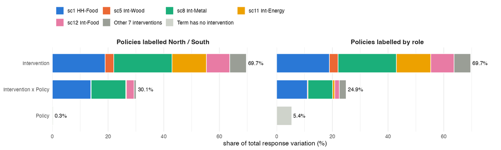

Left: policies named by region. Right: the same runs, with "South adjusts" and "North adjusts" renamed by role in each intervention; the deficit region is the one whose current account the intervention worsens with no rule. Only the labels change, so the intervention share is identical.

#### By outcome block

| Block | Intervention | Policy (by name) | Policy (by role) | Intervention x policy (by name) |
| --- | --- | --- | --- | --- |
| Fiscal | 63.4% | 0.3% | 4.9% | 36.3% |
| Real activity | 66.7% | 0.4% | 9.7% | 32.9% |
| External | 50.7% | 0.3% | 5.1% | 49.0% |
| Ecological | 88.7% | 0.1% | 3.2% | 11.2% |
| Finance and wealth | 79.3% | 0.2% | 3.4% | 20.5% |
| Labour and distribution | 69.2% | 0.3% | 6.1% | 30.5% |

Within each block: the share explained by the twelve interventions, by the policy on its own (two labellings), and by the intervention x policy interaction (policies by name).

How much of the variation in the 74 responses comes from the intervention, from who adjusts, and from their combination. Each response is put on a common scale and the six outcome blocks (activity, fiscal, external, labour and distribution, finance and wealth, ecological) weigh equally. One run per combination, so these are exact shares of this grid, not statistical tests. Each bar is split by the intervention that carries it.

### 180 runs: intervention x who intervenes x policy (current, 2026-11-21)

The full design: twelve interventions, carried out by the North, the South or both, each under five policies (no rule with North money, no rule with South money, and the South, the North or both adjusting under North money). South emissions are corrected (D-77). One run per combination, so the three-way term is what no pair of factors accounts for.

- **The intervention** explains 47.2% of the variation, and **intervention x who intervenes** 73.4%: who carries out the intervention matters almost only through its interaction with what is substituted (on its own, 3.9%).
- **The policies** explain the remaining 26.6%, almost all of it through their interaction with the intervention (10.8%) and the three-way term (9.6%); the policy on its own carries 4.9%. A policy does not have one effect: what it does depends on which region the intervention leaves in deficit, and how much, depends on the current-account gap the intervention opens (Who adjusts tab).
- **Who intervenes x policy** carries 1.3%.

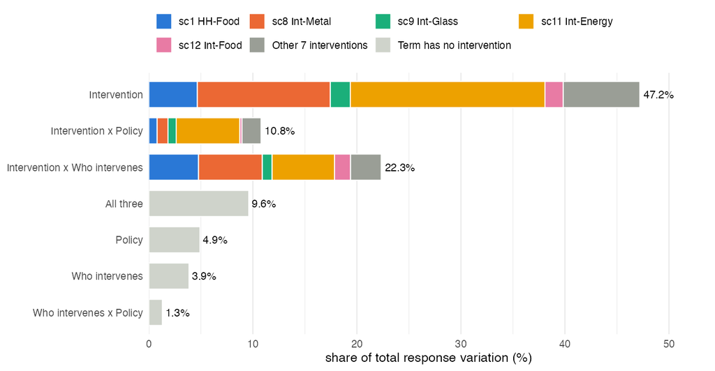

#### By outcome block

| Block | Intervention | + who intervenes | Policies (within) |
| --- | --- | --- | --- |
| Fiscal | 36.7% | 62.1% | 37.9% |
| Real activity | 51.5% | 74.5% | 25.5% |
| External | 31.4% | 55.3% | 44.7% |
| Ecological | 64.2% | 94.8% | 5.2% |
| Finance and wealth | 58.4% | 87.9% | 12.1% |
| Labour and distribution | 41.0% | 65.7% | 34.3% |

Within each block: the share explained by the twelve interventions, by the 36 intervention x who-intervenes cells (cumulative), and what the five policies add within those cells.

**Earlier designs (2026-11-20): the North intervening only.**

### 96 runs: intervention x who adjusts x hierarchy

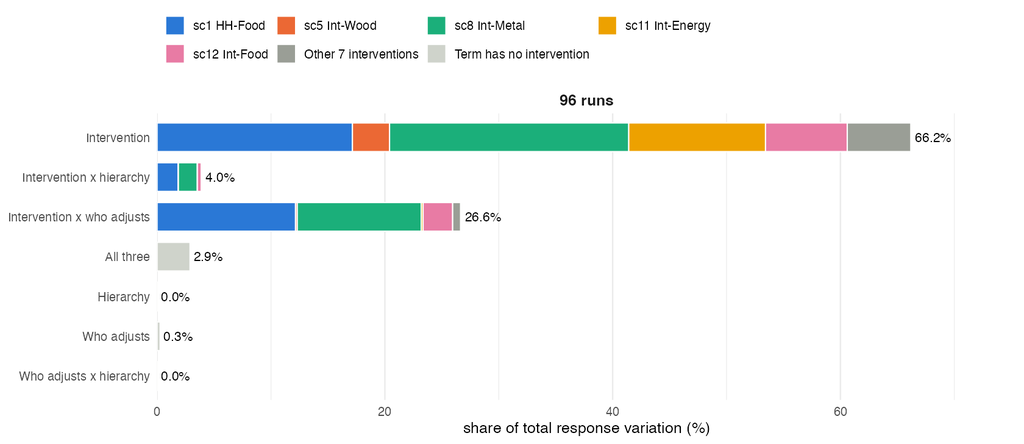

### 60 runs (simplified design): the same rules under two labellings

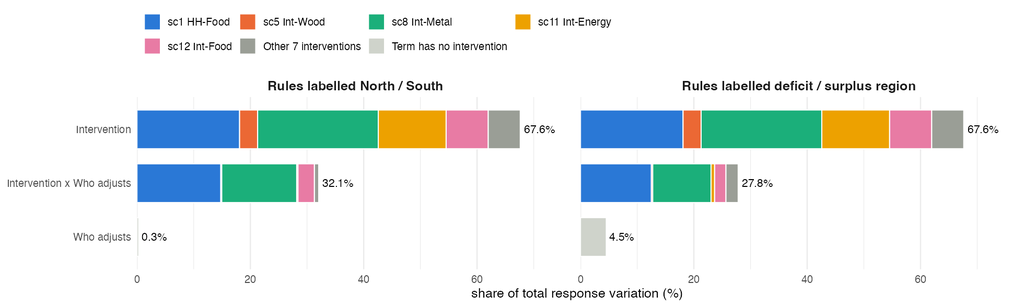

Left: the five cases are no rule (North money), no rule (South money), South adjusts, North adjusts, both adjust. Right: the same runs, with "South adjusts" and "North adjusts" renamed by role in each intervention. The deficit region is the one whose current account the intervention worsens with no rule. Nothing but the labels changes, so the intervention share and the total are identical.

## Dendrograms

Observations Groups 3

Ward linkage on the weighted response space. Each leaf starts with the intervention's pill (number, channel, sector) and its run (who intervenes, policy), and ends with two pills: its group at the chosen cut (G1, G2, ...) and its transmission regime (PL, CD, DC, DE, CC). The dashed line is the cut. Group descriptions are in the **Groups** tab and below the tree.

## Silhouette

The silhouette asks, for each run, whether it sits closer to its own group than to the nearest other group (from -1 to 1). The usual reading (Kaufman and Rousseeuw 1990): above 0.70 strong structure; 0.51-0.70 reasonable; 0.26-0.50 weak; below that, none.

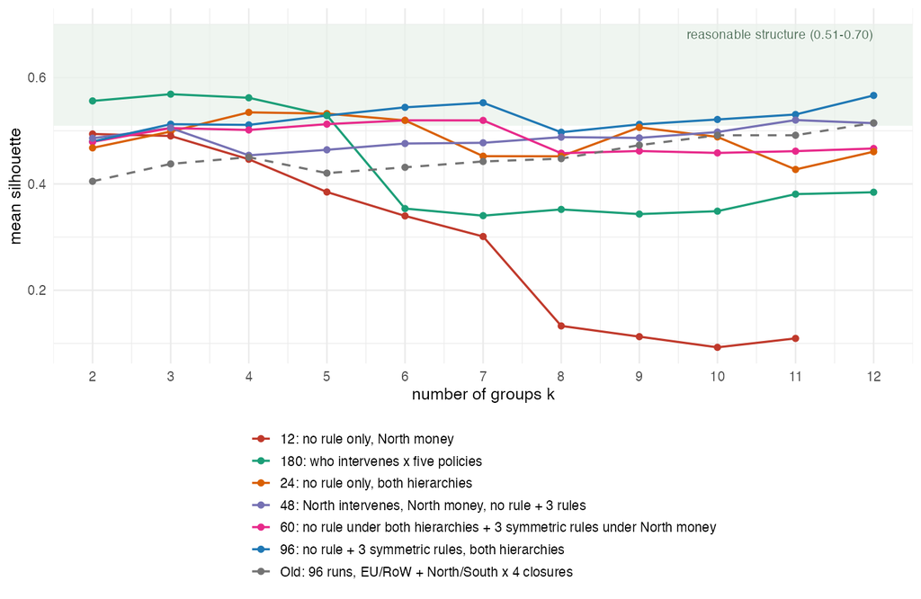

| k | 96 | 60 | 24 | 12 | 180 | 48 |
| --- | --- | --- | --- | --- | --- | --- |
| 2 | 0.480 | 0.479 | 0.468 | 0.494 | 0.556 | 0.486 |
| 3 | 0.512 | 0.505 | 0.499 | 0.490* | 0.569 | 0.505 |
| 4 | 0.511 | 0.502 | 0.535 | 0.446* | 0.562 | 0.454 |
| 5 | 0.529 | 0.512 | 0.532* | 0.385* | 0.529 | 0.464* |
| 6 | 0.544 | 0.520 | 0.520* | 0.340* | 0.354 | 0.476* |
| 7 | 0.553* | 0.520* | 0.452* | 0.301* | 0.340 | 0.477* |
| 8 | 0.497* | 0.458* | 0.452* | 0.133* | 0.352 | 0.488* |
| 9 | 0.512* | 0.462* | 0.506* | 0.113* | 0.343 | 0.487* |
| 10 | 0.521* | 0.458* | 0.488* | 0.093* | 0.349 | 0.498* |
| 11 | 0.531* | 0.462* | 0.427* | 0.109* | 0.381 | 0.520* |
| 12 | 0.566* | 0.467* | 0.461* | NA | 0.384 | 0.514* |

* the cut leaves at least one group of a single run. Old grid (dashed in the figure): 0.405 at k = 2, first reaching 0.5 at k = 12.

### Reading

**180 runs (current).** The best cut is k = 3 (mean silhouette 0.569), and k = 2-4 all sit in the reasonable band (0.556-0.569); from k = 5 the mean falls to 0.529 and then to 0.354 at k = 6. The best cut separates a large mass of small-effect runs from two small groups of runs that move the economy a lot (sc1 HH-Food and sc11 Int-Energy, and separately sc8 Int-Metal, each carried out by the South or both): groups of size, not of design. Regimes on this set are read by role, intervening region against its partner (for both intervening, North against South).

No set reaches strong structure, and no k stands out: the results form a continuum rather than separated groups. The new sets sit a little higher at small k than the old grid (about 0.48-0.53 against 0.41-0.45 for k = 2-5). In the 60-run design k = 6 is the highest cut without single-run groups (0.520), so it is a reasonable cut to read; k = 2-3 are as defensible.

### Do the five regimes form groups?

| Regime | Runs | Mean silhouette of its runs (24 no-rule runs) |
| --- | --- | --- |
| CC | 8 | 0.66 |
| CD | 4 | -0.06 |
| DC | 5 | -0.51 |
| DE | 2 | -0.38 |
| PL | 5 | -0.03 |

Only contained contraction (CC) holds together. The regimes are better read as positions on one continuum, the North's current-account response: production leakage at one end, competitive displacement at the other, contained contraction in the middle. They remain correct as a description of the signs of value added.

## Groups

Observations Groups 3

Each group is named after the response that most distinguishes it and its dominant transmission regime. The chips are the five most distinctive responses: ▲ rise, ▼ fall (green / red when the group moves further than average, with a strength word by distance from the average: slight under 0.5 sd, mild 0.5-1, pronounced 1-1.5, sharp 1.5-2.5, very sharp 2.5 and above); grey hollow arrows when the group moves the same way as the average but less ("milder", or "much milder" beyond 1 sd). Values are the group's mean response and the mean of all runs in the set; "sd" is how far the group sits from that mean, in standard deviations. Responses are in % of the run without the intervention, points (pp) for shares and ratios, or % of value added for balances.

## PCA

Runs

### 48 runs: North intervenes, North money

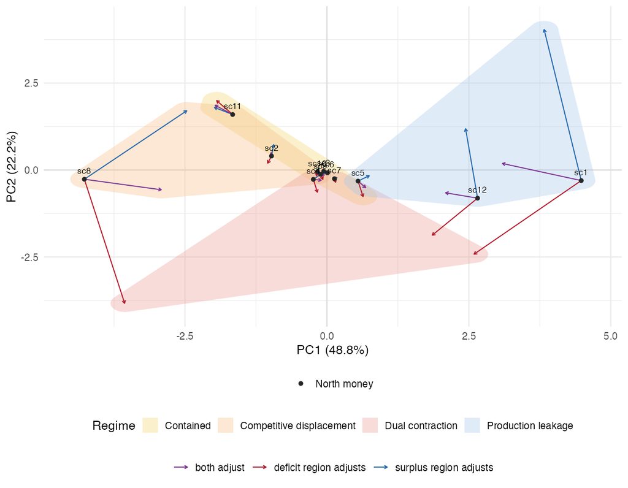

One principal-component analysis of these 48 runs in the 74-response space (South emissions corrected, D-77; six blocks weighted equally), re-standardised over the 48 runs. Shaded: the regimes (North against South). Points: the no-rule runs. Arrows: from the no-rule run under North money to each rule run, coloured by the adjusting region's role.

- **PC1 (48.8%)**: North real final exports (+0.18); South real final imports (+0.18); South fixed capital stock (+0.16); North current account balance (-0.16); South current account balance (+0.16); South real investment in fixed capital (+0.15); North corporate profit (-0.15); South corporate demand for bank loans (+0.15). Its correlation with world value added is -0.55.
- **PC2 (22.2%)**: South net household wealth (+0.21); North real final imports (+0.20); South real final exports (+0.20); South tax payments (+0.19); South government spending (+0.19); South corporate profit (+0.18); North waste (+0.17); South nominal output (+0.17).
- **PC3 (11.8%)**: South trade balance (-0.31); North trade balance (+0.31); South current account balance (-0.23); North current account balance (+0.23); South household demand for personal loans (+0.23); South government deficit (+0.23); North government spending (-0.21); North total real consumption (-0.20).

**What the rules do.** The first common direction of the 36 rule moves (each rule run minus its no-rule run, North money, in all 74 responses) carries 71.6% of their squared length; its absolute cosine with PC1, PC2 and PC3 is 0.28, 0.19 and 0.89.

### 60 runs: North intervenes, both monies

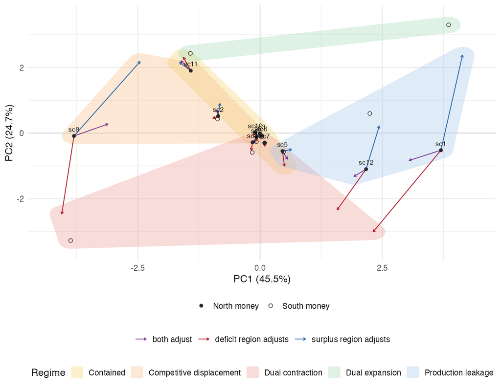

One principal-component analysis of these 60 runs in the 74-response space (South emissions corrected, D-77; six blocks weighted equally), re-standardised over the 60 runs. Shaded: the regimes (North against South). Points: the no-rule runs (filled, North money; open, South money). Arrows: from the no-rule run under North money to each rule run, coloured by the adjusting region's role.

- **PC1 (45.5%)**: North real final exports (+0.19); South real final imports (+0.19); South fixed capital stock (+0.17); South real investment in fixed capital (+0.16); North current account balance (-0.16); South current account balance (+0.16); South corporate demand for bank loans (+0.16); South corporate profit (+0.16). Its correlation with world value added is -0.31.
- **PC2 (24.7%)**: North net household wealth (+0.21); North real final imports (+0.20); South real final exports (+0.20); South household demand for personal loans (+0.19); North household demand for personal loans (+0.19); North value added (+0.18); North corporate demand for bank loans (+0.18); North nominal output (+0.18).
- **PC3 (10.5%)**: North total real consumption (-0.22); North real final imports (-0.20); South real final exports (-0.20); South government spending (-0.20); North worker/capitalist income gap |1 - ydw/ydc| (rises when workers gain) (-0.19); North profit share of disposable income (+0.19); North wage share of disposable income (-0.19); South household demand for personal loans (+0.19).

**What the rules do.** The first common direction of the 36 rule moves (each rule run minus its no-rule run, North money, in all 74 responses) carries 60.4% of their squared length; its absolute cosine with PC1, PC2 and PC3 is 0.15, 0.01 and 0.01.

### 180 runs: one PCA, three panels by who intervenes

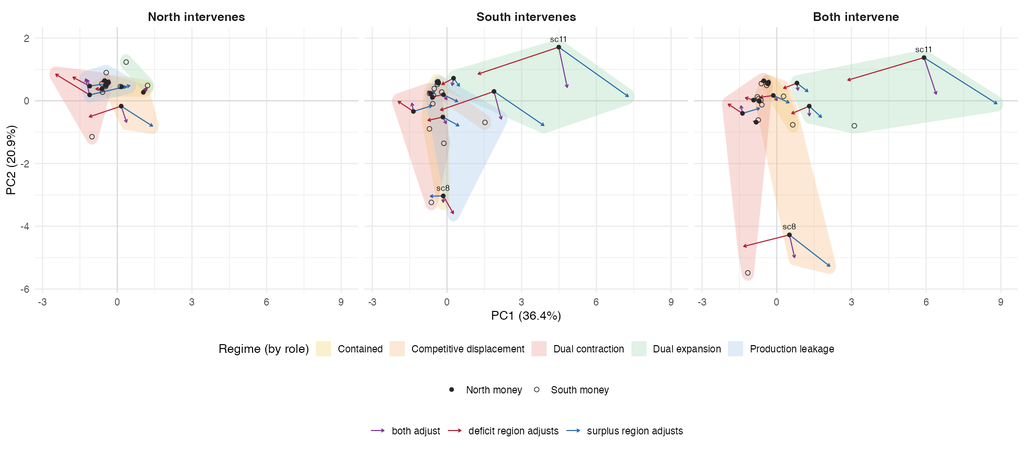

One principal-component analysis of all 180 runs in the 74-response space (South emissions corrected, D-77; six blocks weighted equally), drawn as three panels on the same axes. Shaded: the regimes, read by role (intervener against partner; both intervening, North against South). Points: the no-rule runs (filled, North money; open, South money). Arrows: from the no-rule run under North money to each rule run, coloured by the adjusting region's role.

- **PC1 (36.4%)**: North corporate profit (+0.20); North fixed capital stock (+0.20); North tax payments (+0.20); North net household wealth (+0.20); North corporate demand for bank loans (+0.19); North value added (+0.19); North debt to GDP ratio (-0.19); North nominal output (+0.18). Its correlation with world value added is 0.98.
- **PC2 (20.9%)**: South real final exports (-0.25); North real final imports (-0.25); South household demand for personal loans (-0.24); South corporate profit (+0.22); South tax payments (+0.20); South extraction of matter (+0.20); South production of material goods (+0.20); South net household wealth (+0.20).
- **PC3 (12.6%)**: South current account balance (+0.37); North current account balance (-0.37); South trade balance (+0.36); North trade balance (-0.36); North government deficit (+0.25); South government deficit (-0.24); North government debt (+0.23); South government debt (-0.22).

**What the rules do.** Take each rule run's move from its no-rule run (North money) in all 74 responses. The first common direction of the 108 moves carries 64.7% of their squared length; computed separately for North-, South- and both-intervening runs, the three directions agree to an absolute cosine of at least 0.99. That direction lines up with PC3 (|cos| 0.82; with PC1 0.06, PC2 0.26): the rule mostly shifts *which* budget and current account move, the same way whoever intervened. Its effect on world output is a smaller component, read in **Who adjusts**.

**Earlier design (2026-11-20): the North intervening only.**

Two steps. First the interventions alone, with nobody adjusting. Then what each fiscal rule does to them.

### 1. No rule: the twelve interventions under each hierarchy

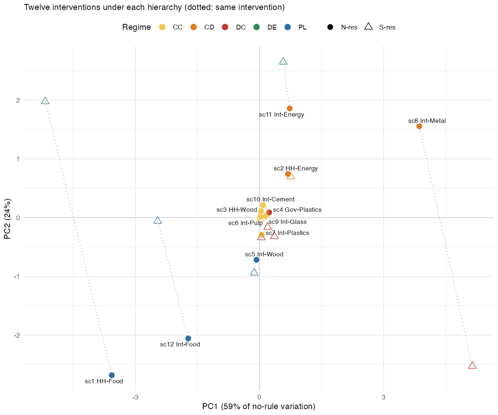

**PC1 (59% of the variation)** is the external and fiscal imbalance the intervention opens: South current account balance (-0.28); North current account balance (+0.28); North trade balance (+0.28); South trade balance (-0.28); North government deficit (-0.22); South government deficit (+0.22); South debt to GDP ratio (+0.22); South government debt (+0.22). **PC2 (24%)** is the distribution and finance side: South household demand for personal loans (+0.30); North household demand for personal loans (+0.24); North net household wealth (+0.23); South worker/capitalist income gap |1 - ydw/ydc| (rises when workers gain) (-0.23); South wage share of disposable income (-0.23); South profit share of disposable income (+0.23); North worker/capitalist income gap |1 - ydw/ydc| (rises when workers gain) (-0.21); North wage share of disposable income (-0.21).

Filled circles are the actual world (North money is the reserve); triangles are the same intervention if South money were the reserve, joined by a dotted line. Production leakage (sc1, sc12) sits on one side of PC1, competitive displacement (sc8, sc2) on the other, contained contraction near the centre. The counterfactual hierarchy moves the large-imbalance interventions a long way (sc1 HH-Food becomes dual expansion, sc8 Int-Metal dual contraction) and the others hardly at all: with nobody adjusting, a fiat reserve gap compounds, and whose money is the reserve decides on which side it compounds.

### 2. What each rule does (North money)

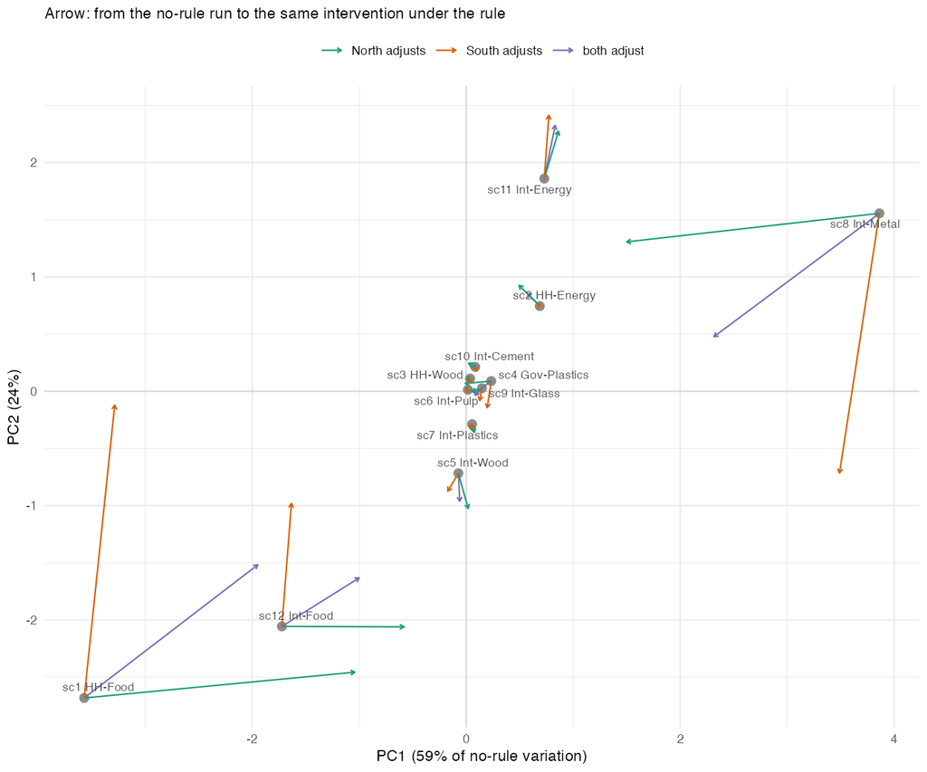

Arrows run from the no-rule run to the same intervention under each rule. In this plane North adjustment pulls the imbalance back towards the centre along PC1, and South adjustment moves results mostly along PC2. But only 21% of the movement lies in this plane: the rules move results mostly in a direction the interventions themselves do not vary along. The **Who adjusts** tab draws that direction.

## Who adjusts

### 180 runs (current): the role law

For every rule run, its world value added minus the same intervention's no-rule run (North money), against the size of the current-account gap the intervention opens with no rule. The roles are read from that no-rule current account, for each intervention and intervening region. A line through the origin fits the single-region runs with slope 18.5 and R² 0.96: the surplus region adjusting raises world output by about 18.5 times the gap, the deficit region adjusting lowers it by the same.

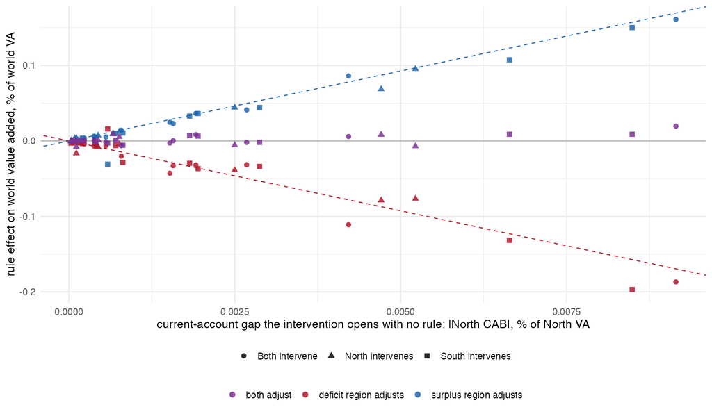

#### Sign of the rule's effect on world value added

| Who adjusts | world VA down | world VA up |
| --- | --- | --- |
| both adjust | 16 | 20 |
| deficit region adjusts | 34 | 2 |
| surplus region adjusts | 2 | 34 |

#### By intervening region and role

|  | world VA down | world VA up |
| --- | --- | --- |
| Both intervene · deficit region adjusts | 12 | 0 |
| Both intervene · surplus region adjusts | 0 | 12 |
| North intervenes · deficit region adjusts | 11 | 1 |
| North intervenes · surplus region adjusts | 1 | 11 |
| South intervenes · deficit region adjusts | 11 | 1 |
| South intervenes · surplus region adjusts | 1 | 11 |

#### The same runs by region name

|  | world VA down | world VA up |
| --- | --- | --- |
| Both intervene · North adjusts | 4 | 8 |
| Both intervene · South adjusts | 8 | 4 |
| North intervenes · North adjusts | 5 | 7 |
| North intervenes · South adjusts | 7 | 5 |
| South intervenes · North adjusts | 4 | 8 |
| South intervenes · South adjusts | 8 | 4 |

- **By role the sign is nearly fixed; by name it is not.** Whether the North or the South adjusting helps world output depends on which of them the intervention leaves in surplus, and that changes with the intervention and with who carries it out.
- **Both adjusting nets to about zero**, with no consistent sign.
- **The size scales with the gap.** South interventions open larger gaps, so their rule effects are larger; the slope is the same.
- **sc8 Int-Metal with the South intervening** is the main exception: its North current account changes sign during the run and the rule reads the accumulated reserve stock, so the adjuster labelled surplus by the window-average current account ends up cutting spending (Main Findings, 7).

**Earlier design (2026-11-20): the North intervening only.**

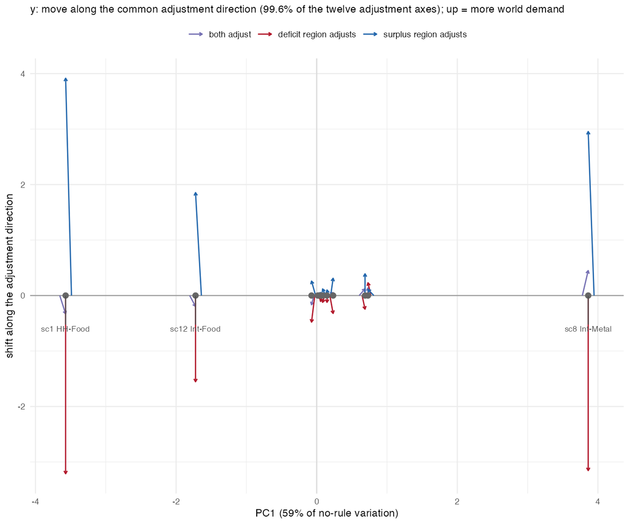

For each intervention, take the difference between "North adjusts" and "South adjusts", and re-sign it so it runs from "the surplus region adjusts" to "the deficit region adjusts" (the deficit region is the one whose current account the intervention worsens). The twelve differences lie on one direction: 99.6% of their variation. That direction is **world demand**: it loads on South government spending; North government spending; North real final imports; South real final exports; South tax payments; North total real consumption; South final demand in real terms; North waste; North gross output; North final demand in real terms.

- **The surplus region adjusts → world demand expands. The deficit region adjusts → it contracts.** Both adjusting nets to about zero.
- **The size of the move grows with the imbalance** (the distance from x = 0). That is why sc1, sc8 and sc12 dominated every earlier measure.
- **The regime decides which region is in deficit.** Under leakage the North is in deficit, so "North adjusts" is contractionary. Under displacement the South is, and the signs flip. That is the cancellation in the average.

### Which region is the surplus region?

It depends on the intervention, through its regime. In production leakage (sc1 HH-Food, sc12 Int-Food, sc5 Int-Wood) the South gains reserves, so the South is the surplus region and South adjustment is the expansionary one. In competitive displacement (sc8 Int-Metal, sc2 HH-Energy) the North gains reserves, so North adjustment is the expansionary one. This is Keynes's point in the clearing-union proposal: if only deficit countries adjust, adjustment is deflationary for everyone; if surplus countries adjust, it is expansionary. The model reproduces it, and adds that a circular-economy intervention decides which country is the surplus country.

Exception: sc11 Int-Energy does not follow the common direction. Not yet checked: the ecological side (Southern emissions fall when the deficit region adjusts; loading -0.13).